# Stock Time Series: A Use of the Lag, Difference, and Sign Data Transformations

In this section, we cover the uses of the **Lag**, **Difference**, and **Sign** data transformations in the creation of a time series of Google stock from April 2014 to April 2015. The time series will color coded to display overall increase and decrease of stock price by month.  
We can start with a basic time series to better understand what we are looking at:

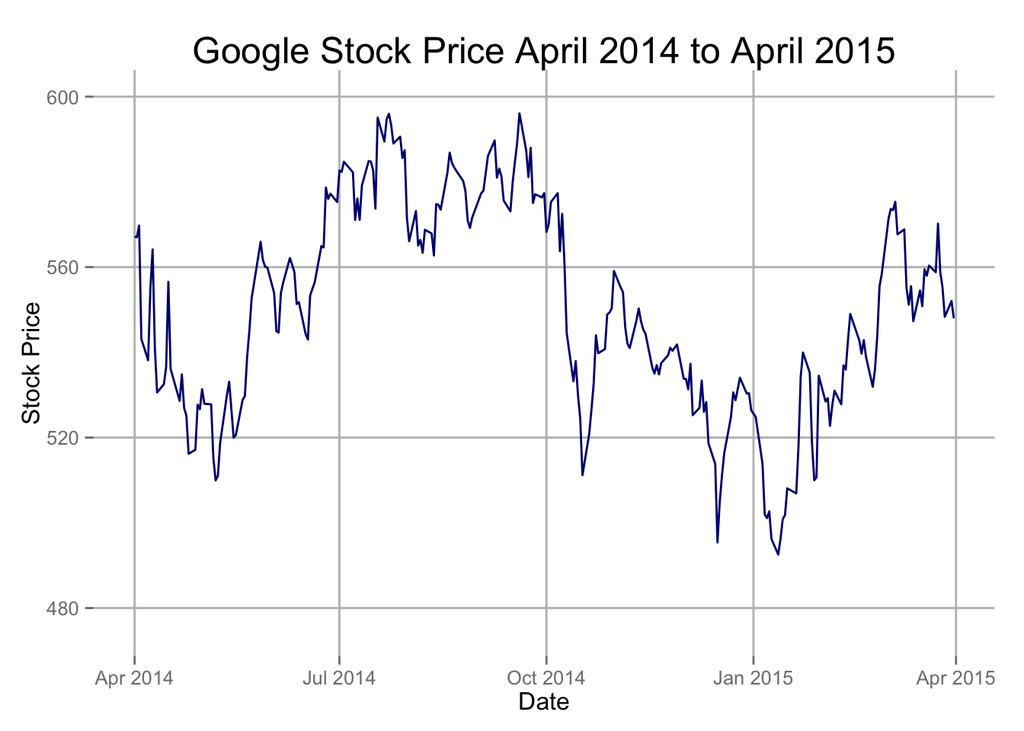

Next, we endeavor to enhance this detailed time series with information about when the stock is increasing or decreasing overall.

```r
#find the last day for each month
stock$lastday <- as.Date(timeLastDayInMonth(stock$Date))

stock$lastdayprice <- 1:252

#set indices of last date to retrieve prices on the last day of the month
temp = 1
for(i in 1:251)
  {
    if(!(stock$lastday[i] == stock$lastday[i+1]))
      {
        stock$lastdayprice[temp:i] <- stock$Adj.Close[i]
        temp = i+1
      }
  }

stock$lastdayprice[temp:252] <- stock$Adj.Close[252]
```

# The Difference Transformation and Lag Transformation

The **difference function**  
*diff(x1, x2,…, xn)*,  
x1-xn vectors  
is relatively self explanatory. We use it to subtract columns of data from one another.

We use the **lag function**  
*lag(x)*, x a vector  
to shift a time series down a column by one unit, replacing the first entry with ‘NA’. This is useful for finding the day to day (or month to month, year to year, etc.) difference between two values. In this case, we use it to shift the column with the stock prices of Google on the last date of each month down an index. We then use the difference function to subtract the lagged column from the original column.

We are now capable of plotting the month to month change of Google stock:

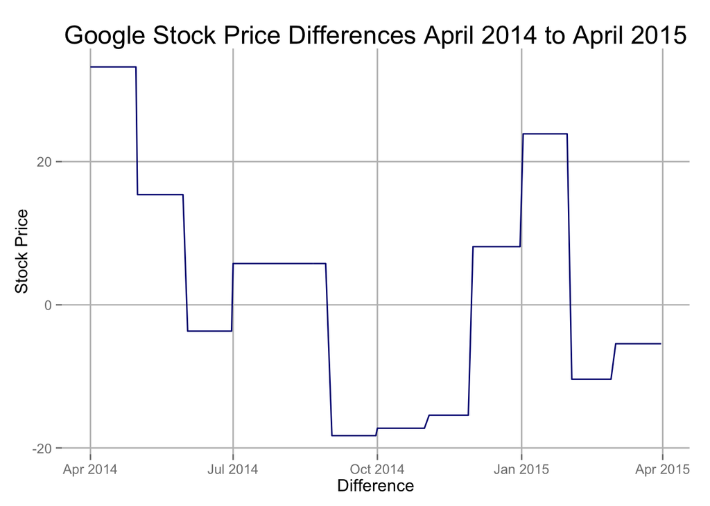

# The Sign Transformation

We use the **sign function**  
*sign(x)*, x a vector  
to simply determine whether a number is positive, negative, or 0 by mapping it to 1, -1, or 0 respectively. In this case, we look at the sign of the month to month difference in the stock price.

```r
#Assign a 1,-1, or 0 to positive, negative, and 0 numbers respectively in the difference column.
stock$sign <- sign(stock$difference)

stock$pos <- stock$Adj.Close
stock$neg <- stock$Adj.Close
```

We are now capable of plotting the sign of the month to month change of Google stock:

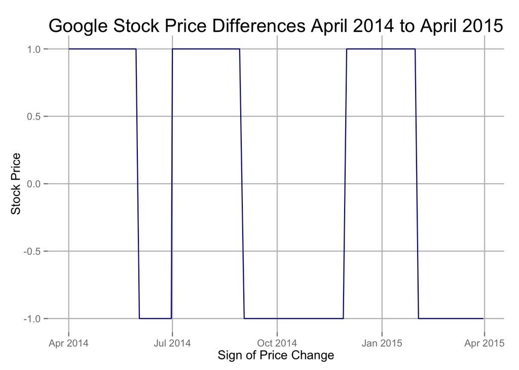

## Here is the final product of our use of the lag, difference, and sign functions:

Where the line is green, Google saw an overall increase in price for that month. Similarly, where the stock is red, Google saw an overall decrease for that month. With a visual like this, we can search for trends in the day to day behavior of a stock during times when it sees an overall increase or decrease.

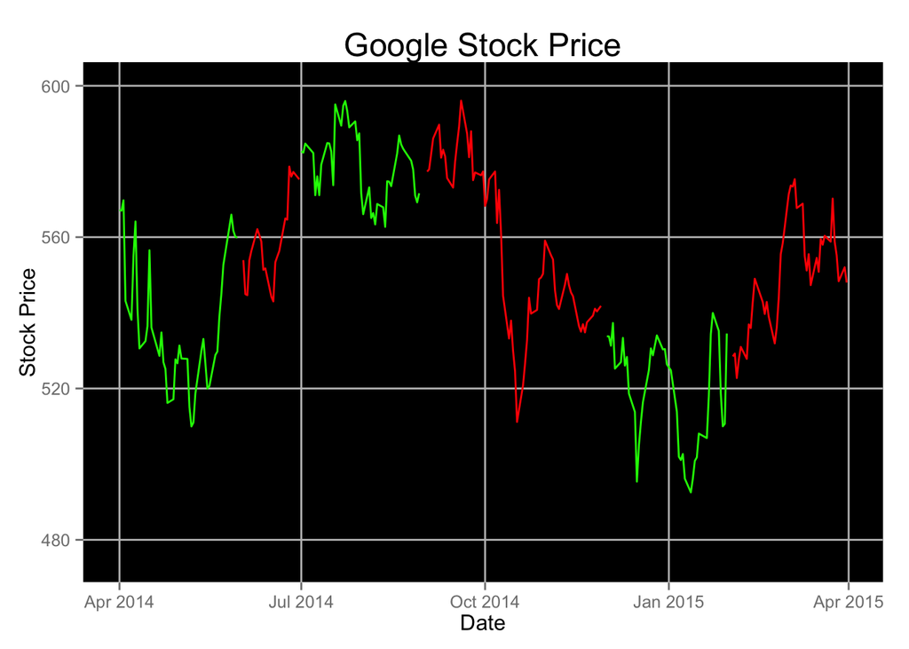